# 2013 The NATO Secretary General’s Annual Report

Mathias Eithz

2022-12-07

Credits: This script is based on Adéla Sobotkovas ‘Text mining, sentiment analysis, and visualization’ (https://github.com/Digital-Methods-HASS/SentimentAnalysis) which is inspired by Allison Horst’s Advanced Statistics and Data Analysis (https://github.com/allisonhorst/esm244-w2020-lab8).

#START

### Get the 2013 Nato General Secretary’s annual report

I will start by retrieving the PDF:

```r
NATO_2013_path <- here("data","NATO_2013.pdf")
NATO_2013_text <- pdf_text(NATO_2013_path)
```

### Some wrangling to split up pages into separate lines:

```r
NATO_2013_df <- data.frame(NATO_2013_text) %>%
  mutate(text_full = str_split(NATO_2013_text, pattern = '\\n')) %>%
  unnest(text_full) %>%
  mutate(text_full = str_trim(text_full))
```

Now each line, on each page, is its own row, with extra starting & trailing spaces removed.

### Get the tokens (individual words) in tidy format

Use `tidytext::unnest_tokens()`, to split columns into tokens. We are interested in *words*, so that’s the token we’ll use:

```r
NATO_2013_tokens <- NATO_2013_df %>%
  unnest_tokens(word, text_full)
```

Wordcount:

```r
NATO_2013_wc <- NATO_2013_tokens %>%
  count(word) %>%
  arrange(-n)
NATO_2013_wc
```

```
## # A tibble: 2,152 × 2
##    word        n
##    <chr>   <int>
##  1 the       660
##  2 and       480
##  3 to        386
##  4 in        371
##  5 of        366
##  6 nato      226
##  7 a         196
##  8 for       124
##  9 2013      121
## 10 defence   105
## # … with 2,142 more rows
```

### Remove stop words:

By removing stopwords, the less interesting words like “the” and “to” etc., disappear in favor of a core of more meaningful words, that will emerge afterwards

We will *remove* stop words using `tidyr::anti_join()`:

```r
NATO_2013_stop <- NATO_2013_tokens %>%
  anti_join(stop_words) %>%
  select(-NATO_2013_text)
```

Now check the counts again:

```r
NATO_2013_swc <- NATO_2013_stop %>%
  count(word) %>%
  arrange(-n)
```

To get rid of all numbers in the `NATO_2013_stop`:

```r
NATO_2013_no_numeric <- NATO_2013_stop %>%
  filter(is.na(as.numeric(word)))
```

### A word cloud of the top 100 most frequent words in the 2013 Nato General Secretary’s annual report

```r
# First I can count the amount of unique words
length(unique(NATO_2013_no_numeric$word))
```

```
## [1] 1768
```

```r
# The number of unique words is 1768, but I only want to include the 100 most freqeuent words:
NATO_2013_top100 <- NATO_2013_no_numeric %>%
  count(word) %>%
  arrange(-n) %>%
  head(100)
```

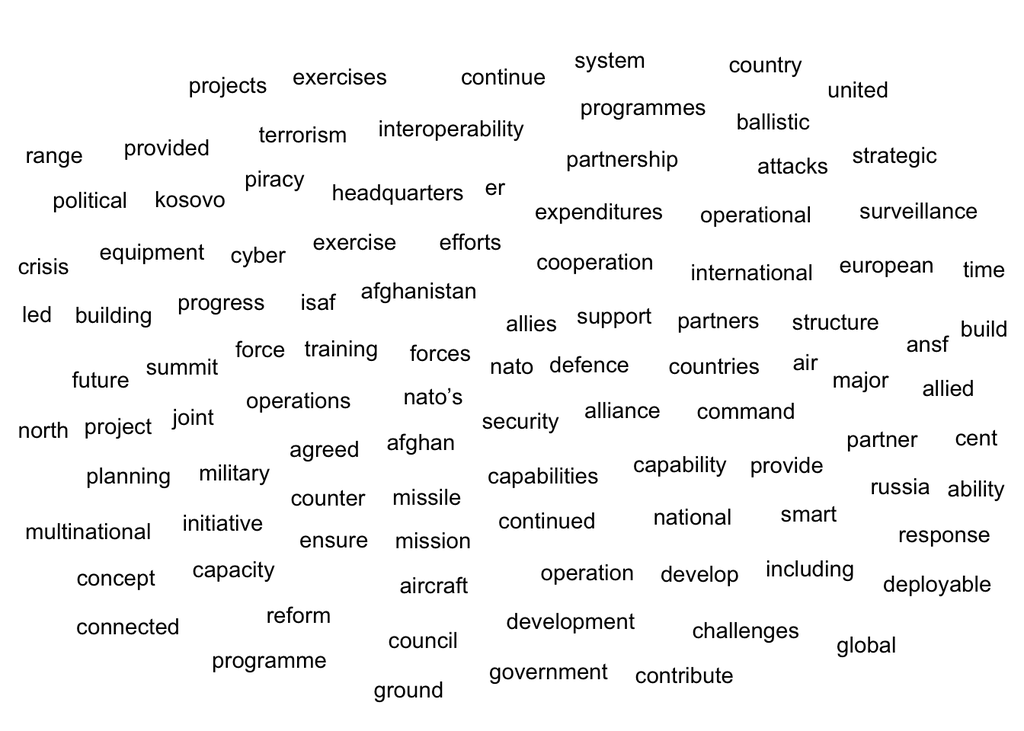

```r
NATO_2013_cloud <- ggplot(data = NATO_2013_top100, aes(label = word)) +
  geom_text_wordcloud() +
  theme_minimal()

NATO_2013_cloud
```

In order to arrange the words so the most frequent words appear more visible than the less frequent words use, color and font size are used as highlighters:

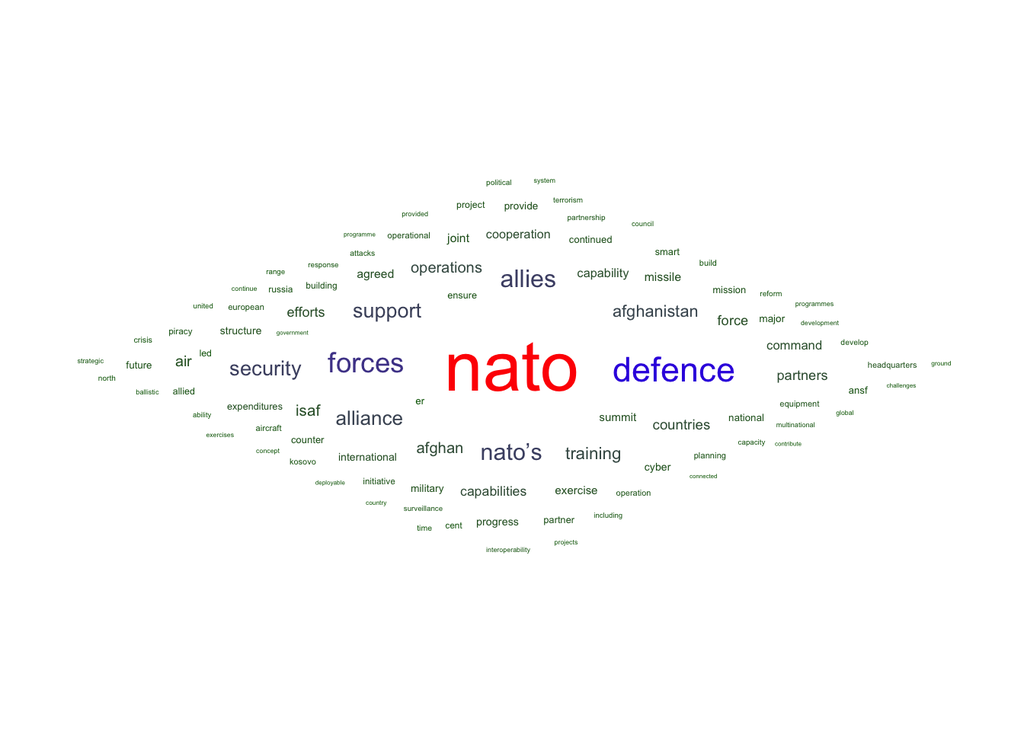

```r
ggplot(data = NATO_2013_top100, aes(label = word, size = n)) +
  geom_text_wordcloud_area(aes(color = n), shape = "diamond") +
  scale_size_area(max_size = 12) +
  scale_color_gradientn(colors = c("darkgreen","blue","red")) +
  theme_minimal()
```

Thereby it is easier for the eye to sort out which words are most frequently appearing and therefore interesting.

# Sentiment analysis

For the Sentiment analysis I will be using the following two general-purpose lexica: - AFINN from Finn Årup Nielsen (https://web.archive.org/web/20220819033824/http://www2.imm.dtu.dk/pubdb/pubs/6010-full.html) - nrc from Saif Mohammad and Peter Turney (https://web.archive.org/web/20221217120738/https://www.saifmohammad.com/WebPages/NRC-Emotion-Lexicon.htm)

### Applying the “afinn” lexicon to the 2013 Nato General Secretary’s annual report

Afinn: Words are ranked from -5 (very negative) to +5 (very positive)

```r
get_sentiments(lexicon = "afinn")
```

```
## # A tibble: 2,477 × 2
##    word       value
##    <chr>      <dbl>
##  1 abandon       -2
##  2 abandoned     -2
##  3 abandons      -2
##  4 abducted      -2
##  5 abduction     -2
##  6 abductions    -2
##  7 abhor         -3
##  8 abhorred      -3
##  9 abhorrent     -3
## 10 abhors        -3
## # … with 2,467 more rows
```

```r
# Note: may be prompted to download (yes)
```

### Applying the “nrc” lexicon to the 2013 Nato General Secretary’s annual report

Nrc: The lexicon includes bins for 8 emotions (anger, anticipation, disgust, fear, joy, sadness, surprise, trust) and positive / negative.

**Citation for NRC lexicon**: Crowdsourcing a Word-Emotion Association Lexicon, Saif Mohammad and Peter Turney, Computational Intelligence, 29 (3), 436-465, 2013.

```r
get_sentiments(lexicon = "nrc")
```

```
## # A tibble: 13,872 × 2
##    word        sentiment
##    <chr>       <chr>
##  1 abacus      trust
##  2 abandon     fear
##  3 abandon     negative
##  4 abandon     sadness
##  5 abandoned   anger
##  6 abandoned   fear
##  7 abandoned   negative
##  8 abandoned   sadness
##  9 abandonment anger
## 10 abandonment fear
## # … with 13,862 more rows
```

## Sentiment analysis using afinn:

First, bind words in `NATO_2013_stop` to `afinn` lexicon:

```r
NATO_2013_afinn <- NATO_2013_stop %>%
  inner_join(get_sentiments("afinn"))
```

Let’s find some sentiment rankings. For comparative reasons I want the results shown in percentage. For his purpose I was inspired by this guide from Statistics Globe: https://web.archive.org/web/20221222105920/https://statisticsglobe.com/change-y-axis-to-percentages-in-ggplot2-barplot-in-r

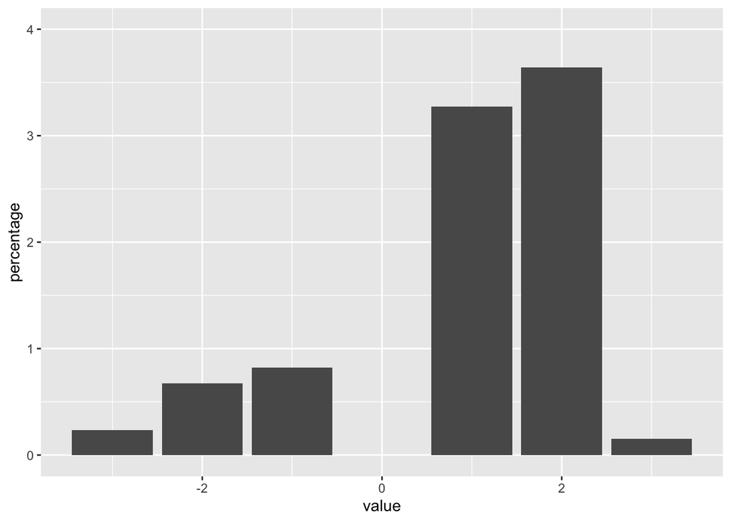

```r
NATO_2013_afinn_hist <- NATO_2013_afinn %>%
count(value, sort = TRUE)

NATO_2013_afinn_hist <- NATO_2013_afinn_hist %>%
mutate(percentage = (n/5958)*100)

# Plot them:
ggplot(data = NATO_2013_afinn_hist, aes(x = value, y = percentage)) +
scale_y_continuous(breaks = seq(0,4,by=1), limits = c(0,4)) +
  geom_col()
```

```r
NATO_2013_afinn2 <- NATO_2013_afinn %>%
  filter(value == 2)
```

It appears that the there is an overweight of more positive words (+1 and +2)

Therefore it is interesting to have a look at which words are actually in this +2 category. I will have the top 10 plotted:

```r
# Check the unique 2-score words:
unique(NATO_2013_afinn2$word)
```

```
##  [1] "ability"       "progress"      "improving"     "effective"
##  [5] "strong"        "robust"        "courage"       "strength"
##  [9] "support"       "effectively"   "strengthen"    "comprehensive"
## [13] "benefits"      "rewards"       "positively"    "inspiration"
## [17] "confidence"    "commitment"    "freedom"       "responsive"
## [21] "improved"      "gain"          "gains"         "endorsed"
## [25] "welcomed"      "supports"      "secure"        "fulfill"
## [29] "landmark"      "resolute"      "stable"        "integrity"
## [33] "improve"       "responsible"   "peace"         "helping"
## [37] "positive"      "strengthening" "importance"    "stronger"
## [41] "strengthened"  "top"           "gained"        "focused"
## [45] "steadfast"     "innovative"    "motivated"     "improves"
## [49] "assets"        "opportunity"   "encouraged"    "opportunities"
## [53] "approved"      "growth"        "encourage"     "meaningful"
## [57] "solidarity"
```

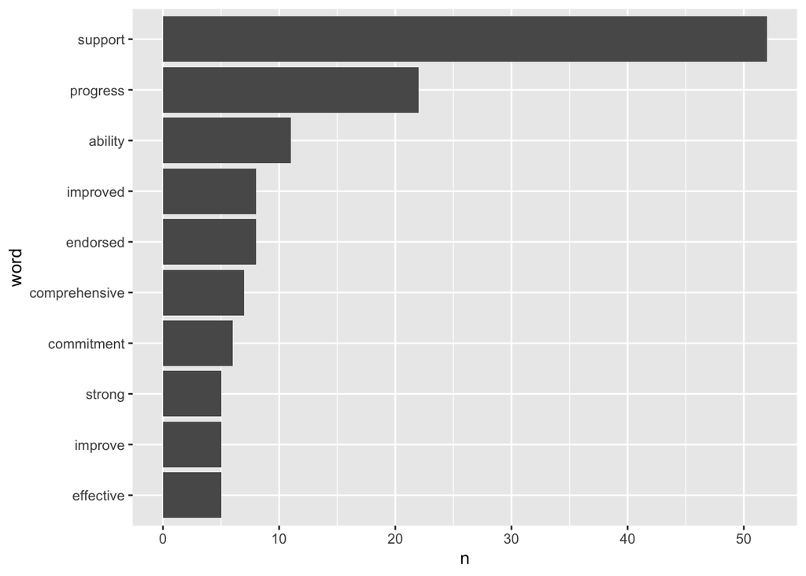

```r
# Count & plot them
NATO_2013_afinn2_n <- NATO_2013_afinn2 %>%
  count(word, sort = TRUE) %>%
  mutate(word = fct_reorder(factor(word), n))%>%
top_n(10) %>%
  ungroup()


ggplot(data = NATO_2013_afinn2_n, aes(x = word, y = n)) +
  geom_col() +
  coord_flip()
```

```r
NATO_2013_afinn_minus2 <- NATO_2013_afinn %>%
  filter(value == -2)
```

```r
# Check the unique minus 2-score words:
unique(NATO_2013_afinn_minus2$word)
```

```
##  [1] "risks"       "threats"     "conflict"    "conflicts"   "threat"
##  [6] "casualty"    "disasters"   "fire"        "disruption"  "disaster"
## [11] "obsolete"    "suicide"     "war"         "exploit"     "grave"
## [16] "risk"        "undermining" "gross"       "negative"
```

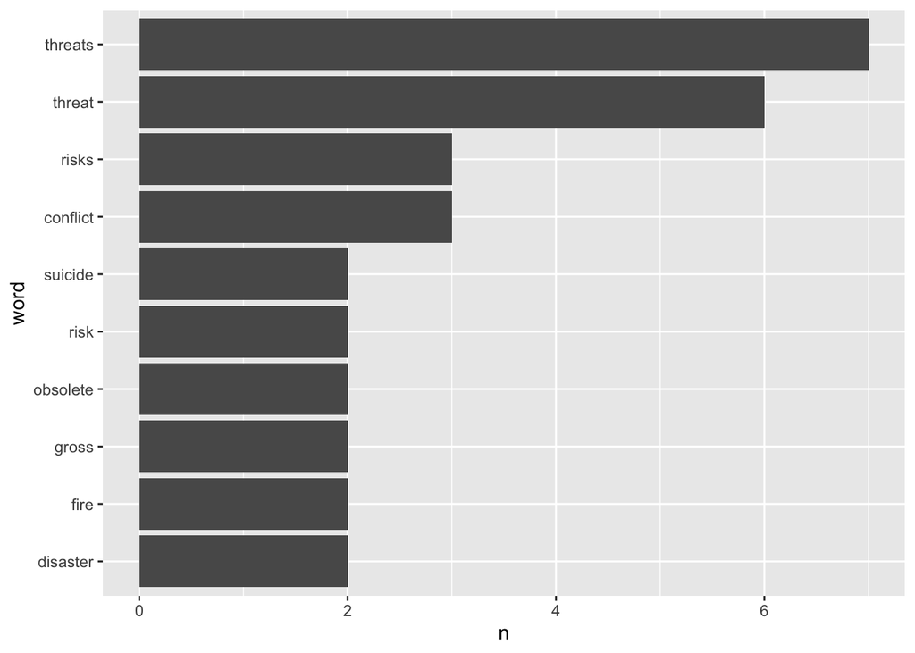

```r
# Count & plot them
NATO_2013_afinn_minus2_n <- NATO_2013_afinn_minus2 %>%
  count(word, sort = TRUE) %>%
  mutate(word = fct_reorder(factor(word), n))%>%
top_n(10) %>%
  ungroup()


ggplot(data = NATO_2013_afinn_minus2_n, aes(x = word, y = n)) +
  geom_col() +
  coord_flip()
```

Summarizing the sentiment of the 2013 Nato General Secretary’s annual report using the afinn lexicon:

```r
NATO_2013_summary <- NATO_2013_afinn %>%
  summarize(
    mean_score = mean(value),
    median_score = median(value)
  )
```

With the mean score being 0.93 an the median score being 1, it can be concluded that the sentiment of the 2013 Nato General Secretary’s annual report is slightly more positive than negative

## Using the NRC lexicon for sentiment analysis

We can use the NRC lexicon to start “binning” text by the feelings they’re typically associated with. As above, we’ll use inner_join() to combine the NATO_2013 non-stopword text with the nrc lexicon:

```r
NATO_2013_nrc <- NATO_2013_stop %>%
  inner_join(get_sentiments("nrc"))
```

By using `anti_join()` it is possible to check which words are excluded:

```r
NATO_2013_exclude <- NATO_2013_stop %>%
  anti_join(get_sentiments("nrc"))

# View(NATO_2013_exclude)

# Count to find the most excluded:
NATO_2013_exclude_n <- NATO_2013_exclude %>%
  count(word, sort = TRUE)

head(NATO_2013_exclude_n)
```

```
## # A tibble: 6 × 2
##   word        n
##   <chr>   <int>
## 1 nato      226
## 2 2013      121
## 3 defence   105
## 4 forces     72
## 5 allies     56
## 6 nato’s     55
```

The words that are most frequently excluded are e.g. “nato”, “2013” and “defence”

Now find some counts:

```r
NATO_2013_nrc_n <- NATO_2013_nrc %>%
  count(sentiment, sort = TRUE)

NATO_2013_nrc_n <- NATO_2013_nrc_n %>%
  mutate(percentage = (n/5958)*100)
```

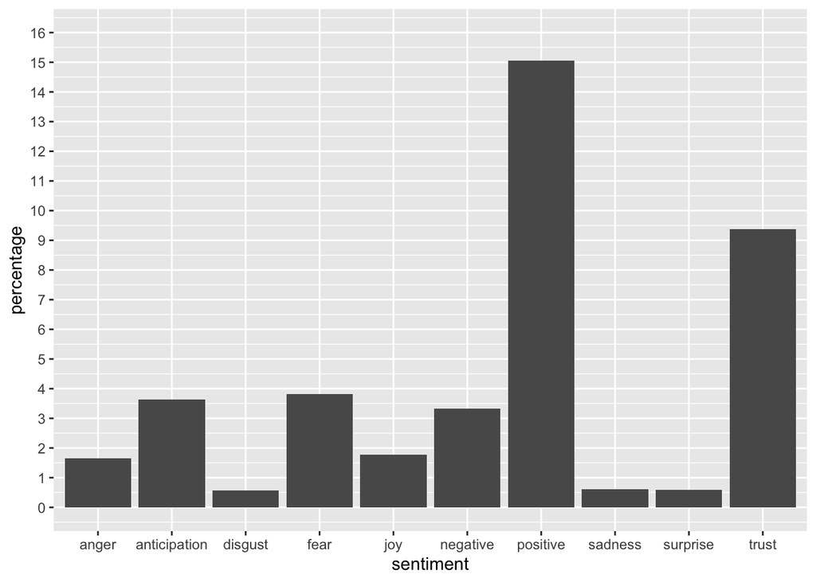

```r
# And plot them:

ggplot(data = NATO_2013_nrc_n, aes(x = sentiment, y = percentage)) +
  scale_y_continuous(breaks = seq(0,16,by=1), limits = c(0,16)) +
  geom_col()
```

The sentiment categories ‘positive’ and ‘trust’ contains the highest percentages of the 10 sentiment categories.

It is also possible to show the top 5 words under each of the 10 sentiment categories:

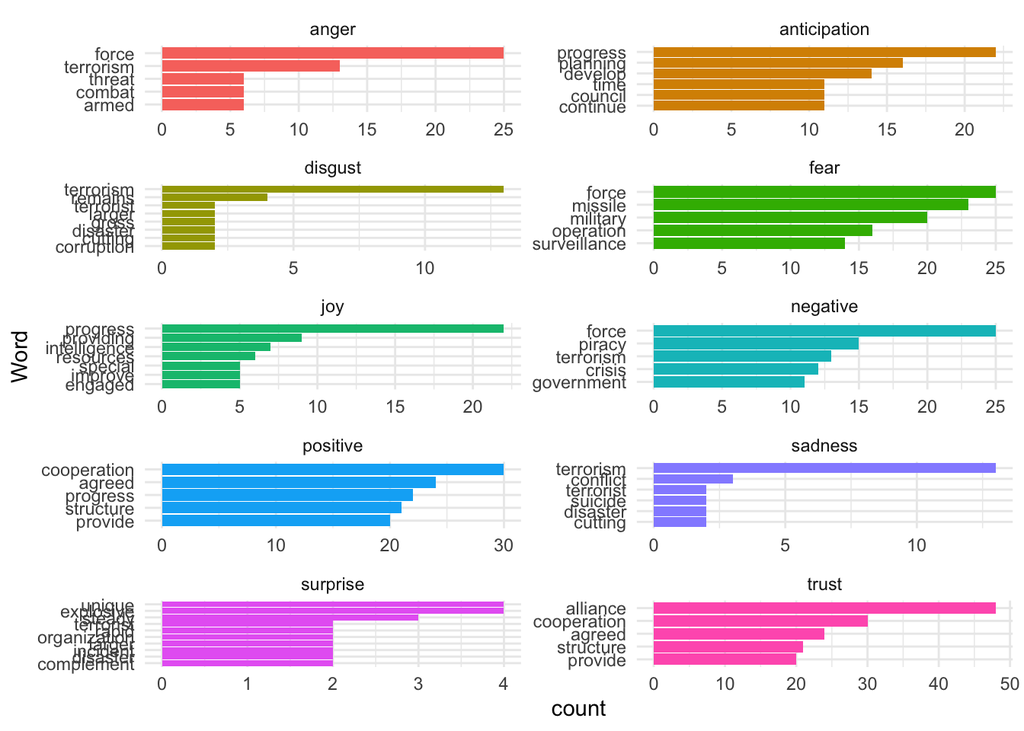

```r
NATO_2013_nrc_n5 <- NATO_2013_nrc %>%
  count(word,sentiment, sort = TRUE) %>%
  group_by(sentiment) %>%
  top_n(5) %>%
  ungroup()

NATO_2013_nrc_gg <- ggplot(data = NATO_2013_nrc_n5, aes(x = reorder(word,n), y = n, fill = sentiment)) +
  geom_col(show.legend = FALSE) +
  facet_wrap(~sentiment, ncol = 2, scales = "free") +
  coord_flip() +
  theme_minimal() +
  labs(x = "Word", y = "count")

# Show it
NATO_2013_nrc_gg
```

```r
# Save it
ggsave(plot = NATO_2013_nrc_gg,
       here("figures","NATO_2013_nrc_sentiment.png"),
       height = 8,
       width = 5)
```